# Optimal Treatment Analysis

## Outcome Variable

**Outcome Variable:** ever_stunted

## Predictor Variables

**Intervention Variable:** safeh20

**Adjustment Set:**

- arm
- sex
- W_mage
- meducyrs
- feducyrs
- hhwealth_quart
- hfoodsec
- W_mhtcm
- W_nrooms
- W_nchldlt5
- W_parity
- impfloor
- impsan
- delta_W_mage
- delta_meducyrs
- delta_feducyrs
- delta_hhwealth_quart
- delta_hfoodsec
- delta_W_mhtcm
- delta_W_nrooms
- delta_W_nchldlt5
- delta_W_parity
- delta_impfloor
- delta_impsan

## Stratifying Variables

The analysis was stratified on these variable(s):

- agecat
- studyid
- country

## Data Summary

| agecat | studyid | country | safeh20 | ever_stunted | n_cell | n |
| --- | --- | --- | --- | --- | --- | --- |
| 0-24 months (no birth st.) | ki0047075b-MAL-ED | BANGLADESH | 1 | 0 | 0 | 203 |
| 0-24 months (no birth st.) | ki0047075b-MAL-ED | BANGLADESH | 1 | 1 | 0 | 203 |
| 0-24 months (no birth st.) | ki0047075b-MAL-ED | BANGLADESH | 0 | 0 | 94 | 203 |
| 0-24 months (no birth st.) | ki0047075b-MAL-ED | BANGLADESH | 0 | 1 | 109 | 203 |
| 0-24 months (no birth st.) | ki0047075b-MAL-ED | BRAZIL | 1 | 0 | 0 | 131 |
| 0-24 months (no birth st.) | ki0047075b-MAL-ED | BRAZIL | 1 | 1 | 0 | 131 |
| 0-24 months (no birth st.) | ki0047075b-MAL-ED | BRAZIL | 0 | 0 | 115 | 131 |
| 0-24 months (no birth st.) | ki0047075b-MAL-ED | BRAZIL | 0 | 1 | 16 | 131 |
| 0-24 months (no birth st.) | ki0047075b-MAL-ED | INDIA | 1 | 0 | 0 | 196 |
| 0-24 months (no birth st.) | ki0047075b-MAL-ED | INDIA | 1 | 1 | 0 | 196 |
| 0-24 months (no birth st.) | ki0047075b-MAL-ED | INDIA | 0 | 0 | 91 | 196 |
| 0-24 months (no birth st.) | ki0047075b-MAL-ED | INDIA | 0 | 1 | 105 | 196 |
| 0-24 months (no birth st.) | ki0047075b-MAL-ED | NEPAL | 1 | 0 | 0 | 207 |
| 0-24 months (no birth st.) | ki0047075b-MAL-ED | NEPAL | 1 | 1 | 1 | 207 |
| 0-24 months (no birth st.) | ki0047075b-MAL-ED | NEPAL | 0 | 0 | 153 | 207 |
| 0-24 months (no birth st.) | ki0047075b-MAL-ED | NEPAL | 0 | 1 | 53 | 207 |
| 0-24 months (no birth st.) | ki0047075b-MAL-ED | PERU | 1 | 0 | 5 | 229 |
| 0-24 months (no birth st.) | ki0047075b-MAL-ED | PERU | 1 | 1 | 5 | 229 |
| 0-24 months (no birth st.) | ki0047075b-MAL-ED | PERU | 0 | 0 | 84 | 229 |
| 0-24 months (no birth st.) | ki0047075b-MAL-ED | PERU | 0 | 1 | 135 | 229 |
| 0-24 months (no birth st.) | ki0047075b-MAL-ED | SOUTH AFRICA | 1 | 0 | 19 | 230 |
| 0-24 months (no birth st.) | ki0047075b-MAL-ED | SOUTH AFRICA | 1 | 1 | 16 | 230 |
| 0-24 months (no birth st.) | ki0047075b-MAL-ED | SOUTH AFRICA | 0 | 0 | 81 | 230 |
| 0-24 months (no birth st.) | ki0047075b-MAL-ED | SOUTH AFRICA | 0 | 1 | 114 | 230 |
| 0-24 months (no birth st.) | ki0047075b-MAL-ED | TANZANIA, UNITED REPUBLIC OF | 1 | 0 | 24 | 210 |
| 0-24 months (no birth st.) | ki0047075b-MAL-ED | TANZANIA, UNITED REPUBLIC OF | 1 | 1 | 125 | 210 |
| 0-24 months (no birth st.) | ki0047075b-MAL-ED | TANZANIA, UNITED REPUBLIC OF | 0 | 0 | 11 | 210 |
| 0-24 months (no birth st.) | ki0047075b-MAL-ED | TANZANIA, UNITED REPUBLIC OF | 0 | 1 | 50 | 210 |
| 0-24 months (no birth st.) | ki1000304b-SAS-FoodSuppl | INDIA | 1 | 0 | 72 | 257 |
| 0-24 months (no birth st.) | ki1000304b-SAS-FoodSuppl | INDIA | 1 | 1 | 185 | 257 |

[output cut: 150 more lines]

The following strata were considered:

- agecat: 0-24 months (no birth st.), studyid: ki0047075b-MAL-ED, country: BANGLADESH
- agecat: 0-24 months (no birth st.), studyid: ki0047075b-MAL-ED, country: BRAZIL
- agecat: 0-24 months (no birth st.), studyid: ki0047075b-MAL-ED, country: INDIA
- agecat: 0-24 months (no birth st.), studyid: ki0047075b-MAL-ED, country: NEPAL
- agecat: 0-24 months (no birth st.), studyid: ki0047075b-MAL-ED, country: PERU
- agecat: 0-24 months (no birth st.), studyid: ki0047075b-MAL-ED, country: SOUTH AFRICA
- agecat: 0-24 months (no birth st.), studyid: ki0047075b-MAL-ED, country: TANZANIA, UNITED REPUBLIC OF
- agecat: 0-24 months (no birth st.), studyid: ki1000304b-SAS-FoodSuppl, country: INDIA
- agecat: 0-24 months (no birth st.), studyid: ki1017093-NIH-Birth, country: BANGLADESH
- agecat: 0-24 months (no birth st.), studyid: ki1017093b-PROVIDE, country: BANGLADESH
- agecat: 0-24 months (no birth st.), studyid: ki1017093c-NIH-Crypto, country: BANGLADESH
- agecat: 0-24 months (no birth st.), studyid: ki1114097-CONTENT, country: PERU
- agecat: 0-24 months (no birth st.), studyid: ki1148112-LCNI-5, country: MALAWI
- agecat: 0-24 months (no birth st.), studyid: kiGH5241-JiVitA-3, country: BANGLADESH
- agecat: 0-24 months (no birth st.), studyid: kiGH5241-JiVitA-4, country: BANGLADESH
- agecat: 0-6 months (no birth st.), studyid: ki0047075b-MAL-ED, country: BANGLADESH
- agecat: 0-6 months (no birth st.), studyid: ki0047075b-MAL-ED, country: BRAZIL
- agecat: 0-6 months (no birth st.), studyid: ki0047075b-MAL-ED, country: INDIA
- agecat: 0-6 months (no birth st.), studyid: ki0047075b-MAL-ED, country: NEPAL
- agecat: 0-6 months (no birth st.), studyid: ki0047075b-MAL-ED, country: PERU
- agecat: 0-6 months (no birth st.), studyid: ki0047075b-MAL-ED, country: SOUTH AFRICA
- agecat: 0-6 months (no birth st.), studyid: ki0047075b-MAL-ED, country: TANZANIA, UNITED REPUBLIC OF
- agecat: 0-6 months (no birth st.), studyid: ki1000304b-SAS-FoodSuppl, country: INDIA
- agecat: 0-6 months (no birth st.), studyid: ki1017093-NIH-Birth, country: BANGLADESH
- agecat: 0-6 months (no birth st.), studyid: ki1017093b-PROVIDE, country: BANGLADESH
- agecat: 0-6 months (no birth st.), studyid: ki1017093c-NIH-Crypto, country: BANGLADESH
- agecat: 0-6 months (no birth st.), studyid: ki1114097-CONTENT, country: PERU
- agecat: 0-6 months (no birth st.), studyid: ki1148112-LCNI-5, country: MALAWI
- agecat: 0-6 months (no birth st.), studyid: kiGH5241-JiVitA-3, country: BANGLADESH
- agecat: 0-6 months (no birth st.), studyid: kiGH5241-JiVitA-4, country: BANGLADESH
- agecat: 6-24 months, studyid: ki0047075b-MAL-ED, country: BANGLADESH
- agecat: 6-24 months, studyid: ki0047075b-MAL-ED, country: BRAZIL
- agecat: 6-24 months, studyid: ki0047075b-MAL-ED, country: INDIA
- agecat: 6-24 months, studyid: ki0047075b-MAL-ED, country: NEPAL
- agecat: 6-24 months, studyid: ki0047075b-MAL-ED, country: PERU
- agecat: 6-24 months, studyid: ki0047075b-MAL-ED, country: SOUTH AFRICA
- agecat: 6-24 months, studyid: ki0047075b-MAL-ED, country: TANZANIA, UNITED REPUBLIC OF
- agecat: 6-24 months, studyid: ki1000304b-SAS-FoodSuppl, country: INDIA
- agecat: 6-24 months, studyid: ki1017093-NIH-Birth, country: BANGLADESH
- agecat: 6-24 months, studyid: ki1017093b-PROVIDE, country: BANGLADESH
- agecat: 6-24 months, studyid: ki1017093c-NIH-Crypto, country: BANGLADESH
- agecat: 6-24 months, studyid: ki1114097-CONTENT, country: PERU
- agecat: 6-24 months, studyid: ki1148112-LCNI-5, country: MALAWI
- agecat: 6-24 months, studyid: kiGH5241-JiVitA-3, country: BANGLADESH
- agecat: 6-24 months, studyid: kiGH5241-JiVitA-4, country: BANGLADESH

### Dropped Strata

Some strata were dropped due to rare outcomes:

- agecat: 0-24 months (no birth st.), studyid: ki0047075b-MAL-ED, country: BANGLADESH
- agecat: 0-24 months (no birth st.), studyid: ki0047075b-MAL-ED, country: BRAZIL
- agecat: 0-24 months (no birth st.), studyid: ki0047075b-MAL-ED, country: INDIA
- agecat: 0-24 months (no birth st.), studyid: ki0047075b-MAL-ED, country: NEPAL
- agecat: 0-24 months (no birth st.), studyid: ki1000304b-SAS-FoodSuppl, country: INDIA
- agecat: 0-24 months (no birth st.), studyid: ki1017093-NIH-Birth, country: BANGLADESH
- agecat: 0-24 months (no birth st.), studyid: ki1017093b-PROVIDE, country: BANGLADESH
- agecat: 0-24 months (no birth st.), studyid: ki1017093c-NIH-Crypto, country: BANGLADESH
- agecat: 0-24 months (no birth st.), studyid: ki1114097-CONTENT, country: PERU
- agecat: 0-24 months (no birth st.), studyid: kiGH5241-JiVitA-4, country: BANGLADESH
- agecat: 0-6 months (no birth st.), studyid: ki0047075b-MAL-ED, country: BANGLADESH
- agecat: 0-6 months (no birth st.), studyid: ki0047075b-MAL-ED, country: BRAZIL
- agecat: 0-6 months (no birth st.), studyid: ki0047075b-MAL-ED, country: INDIA
- agecat: 0-6 months (no birth st.), studyid: ki0047075b-MAL-ED, country: NEPAL
- agecat: 0-6 months (no birth st.), studyid: ki1000304b-SAS-FoodSuppl, country: INDIA
- agecat: 0-6 months (no birth st.), studyid: ki1017093-NIH-Birth, country: BANGLADESH
- agecat: 0-6 months (no birth st.), studyid: ki1017093b-PROVIDE, country: BANGLADESH
- agecat: 0-6 months (no birth st.), studyid: ki1017093c-NIH-Crypto, country: BANGLADESH
- agecat: 0-6 months (no birth st.), studyid: ki1114097-CONTENT, country: PERU
- agecat: 0-6 months (no birth st.), studyid: ki1148112-LCNI-5, country: MALAWI
- agecat: 0-6 months (no birth st.), studyid: kiGH5241-JiVitA-3, country: BANGLADESH
- agecat: 0-6 months (no birth st.), studyid: kiGH5241-JiVitA-4, country: BANGLADESH
- agecat: 6-24 months, studyid: ki0047075b-MAL-ED, country: BANGLADESH
- agecat: 6-24 months, studyid: ki0047075b-MAL-ED, country: BRAZIL
- agecat: 6-24 months, studyid: ki0047075b-MAL-ED, country: INDIA
- agecat: 6-24 months, studyid: ki0047075b-MAL-ED, country: NEPAL
- agecat: 6-24 months, studyid: ki0047075b-MAL-ED, country: PERU
- agecat: 6-24 months, studyid: ki1000304b-SAS-FoodSuppl, country: INDIA
- agecat: 6-24 months, studyid: ki1017093-NIH-Birth, country: BANGLADESH
- agecat: 6-24 months, studyid: ki1017093b-PROVIDE, country: BANGLADESH
- agecat: 6-24 months, studyid: ki1017093c-NIH-Crypto, country: BANGLADESH
- agecat: 6-24 months, studyid: ki1114097-CONTENT, country: PERU
- agecat: 6-24 months, studyid: kiGH5241-JiVitA-3, country: BANGLADESH
- agecat: 6-24 months, studyid: kiGH5241-JiVitA-4, country: BANGLADESH

## Methods Detail

We’re interested in the causal parameters $E[Y_a]$ for all values of $a \in \mathcal{A}$. These parameters represent the mean outcome if, possibly contrary to fact, we intervened to set all units to have $A=a$. Under the randomization and positivity assumptions, these are identified by the statistical parameters $\psi_a=E_W[E_{Y|A,W}(Y|A=a,W)]$. In addition, we’re interested in the mean of $Y$, $E[Y]$ under no intervention (the observed mean). We will estimate these parameters by using SuperLearner to fit the relevant likelihood factors – $E_{Y|A,W}(Y|A=a,W)$ and $p(A=a|W)$, and then updating our likelihood fit using a joint TMLE.

For unadjusted analyses ($W=\{\}$), initial likelihoods were estimated using Lrnr_glm to estimate the simple $E(Y|A)$ and Lrnr_mean to estimate $p(A)$. For adjusted analyses, a small library containing Lrnr_glmnet, Lrnr_xgboost, and Lrnr_mean was used.

Having estimated these parameters, we will then use the delta method to estimate relative risks and attributable risks relative to a prespecified baseline level of $A$.

# Results Detail

## Results Plots

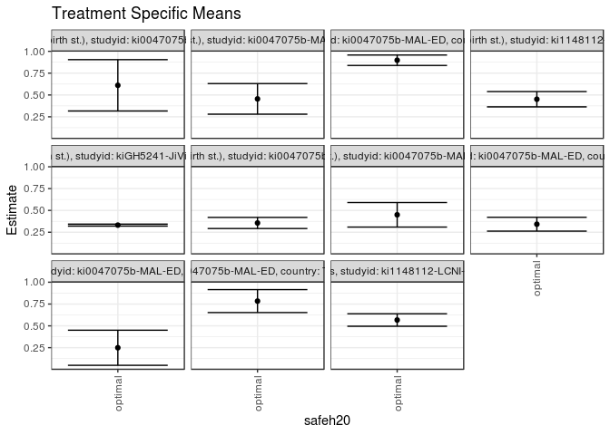

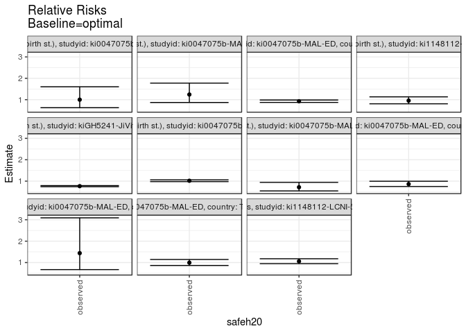

## Results Table

### Parameter: TSM

| agecat | studyid | country | intervention_level | baseline_level | estimate | ci_lower | ci_upper |
| --- | --- | --- | --- | --- | --- | --- | --- |
| 0-24 months (no birth st.) | ki0047075b-MAL-ED | PERU | optimal | NA | 0.6104816 | 0.3165989 | 0.9043642 |
| 0-24 months (no birth st.) | ki0047075b-MAL-ED | SOUTH AFRICA | optimal | NA | 0.4551911 | 0.2799538 | 0.6304284 |
| 0-24 months (no birth st.) | ki0047075b-MAL-ED | TANZANIA, UNITED REPUBLIC OF | optimal | NA | 0.8979235 | 0.8379836 | 0.9578635 |
| 0-24 months (no birth st.) | ki1148112-LCNI-5 | MALAWI | optimal | NA | 0.4513067 | 0.3636076 | 0.5390058 |
| 0-24 months (no birth st.) | kiGH5241-JiVitA-3 | BANGLADESH | optimal | NA | 0.3315339 | 0.3204707 | 0.3425971 |
| 0-6 months (no birth st.) | ki0047075b-MAL-ED | PERU | optimal | NA | 0.3561109 | 0.2925316 | 0.4196902 |
| 0-6 months (no birth st.) | ki0047075b-MAL-ED | SOUTH AFRICA | optimal | NA | 0.4497446 | 0.3092266 | 0.5902626 |
| 0-6 months (no birth st.) | ki0047075b-MAL-ED | TANZANIA, UNITED REPUBLIC OF | optimal | NA | 0.3419365 | 0.2627865 | 0.4210865 |
| 6-24 months | ki0047075b-MAL-ED | SOUTH AFRICA | optimal | NA | 0.2492856 | 0.0483002 | 0.4502711 |
| 6-24 months | ki0047075b-MAL-ED | TANZANIA, UNITED REPUBLIC OF | optimal | NA | 0.7836988 | 0.6523862 | 0.9150114 |
| 6-24 months | ki1148112-LCNI-5 | MALAWI | optimal | NA | 0.5670185 | 0.4954492 | 0.6385878 |

### Parameter: E(Y)

| agecat | studyid | country | intervention_level | baseline_level | estimate | ci_lower | ci_upper |
| --- | --- | --- | --- | --- | --- | --- | --- |
| 0-24 months (no birth st.) | ki0047075b-MAL-ED | PERU | observed | NA | 0.6113537 | 0.5480828 | 0.6746246 |
| 0-24 months (no birth st.) | ki0047075b-MAL-ED | SOUTH AFRICA | observed | NA | 0.5652174 | 0.5010116 | 0.6294232 |
| 0-24 months (no birth st.) | ki0047075b-MAL-ED | TANZANIA, UNITED REPUBLIC OF | observed | NA | 0.8333333 | 0.7828081 | 0.8838586 |
| 0-24 months (no birth st.) | ki1148112-LCNI-5 | MALAWI | observed | NA | 0.4318618 | 0.3892877 | 0.4744359 |
| 0-24 months (no birth st.) | kiGH5241-JiVitA-3 | BANGLADESH | observed | NA | 0.2535639 | 0.2457706 | 0.2613571 |
| 0-6 months (no birth st.) | ki0047075b-MAL-ED | PERU | observed | NA | 0.3624454 | 0.3000489 | 0.4248420 |
| 0-6 months (no birth st.) | ki0047075b-MAL-ED | SOUTH AFRICA | observed | NA | 0.3217391 | 0.2612356 | 0.3822427 |
| 0-6 months (no birth st.) | ki0047075b-MAL-ED | TANZANIA, UNITED REPUBLIC OF | observed | NA | 0.2952381 | 0.2333963 | 0.3570799 |
| 6-24 months | ki0047075b-MAL-ED | SOUTH AFRICA | observed | NA | 0.3589744 | 0.2834562 | 0.4344926 |
| 6-24 months | ki0047075b-MAL-ED | TANZANIA, UNITED REPUBLIC OF | observed | NA | 0.7793103 | 0.7115754 | 0.8470453 |
| 6-24 months | ki1148112-LCNI-5 | MALAWI | observed | NA | 0.6000000 | 0.5639396 | 0.6360604 |

### Parameter: RR

| agecat | studyid | country | intervention_level | baseline_level | estimate | ci_lower | ci_upper |
| --- | --- | --- | --- | --- | --- | --- | --- |
| 0-24 months (no birth st.) | ki0047075b-MAL-ED | PERU | observed | optimal | 1.0014286 | 0.6251404 | 1.6042145 |
| 0-24 months (no birth st.) | ki0047075b-MAL-ED | SOUTH AFRICA | observed | optimal | 1.2417145 | 0.8695502 | 1.7731637 |
| 0-24 months (no birth st.) | ki0047075b-MAL-ED | TANZANIA, UNITED REPUBLIC OF | observed | optimal | 0.9280671 | 0.8733132 | 0.9862540 |
| 0-24 months (no birth st.) | ki1148112-LCNI-5 | MALAWI | observed | optimal | 0.9569142 | 0.8083753 | 1.1327470 |
| 0-24 months (no birth st.) | kiGH5241-JiVitA-3 | BANGLADESH | observed | optimal | 0.7648203 | 0.7395039 | 0.7910033 |
| 0-6 months (no birth st.) | ki0047075b-MAL-ED | PERU | observed | optimal | 1.0177880 | 0.9775145 | 1.0597208 |
| 0-6 months (no birth st.) | ki0047075b-MAL-ED | SOUTH AFRICA | observed | optimal | 0.7153819 | 0.5440167 | 0.9407270 |
| 0-6 months (no birth st.) | ki0047075b-MAL-ED | TANZANIA, UNITED REPUBLIC OF | observed | optimal | 0.8634296 | 0.7495070 | 0.9946680 |
| 6-24 months | ki0047075b-MAL-ED | SOUTH AFRICA | observed | optimal | 1.4400122 | 0.6710782 | 3.0900054 |
| 6-24 months | ki0047075b-MAL-ED | TANZANIA, UNITED REPUBLIC OF | observed | optimal | 0.9944003 | 0.8644116 | 1.1439365 |
| 6-24 months | ki1148112-LCNI-5 | MALAWI | observed | optimal | 1.0581665 | 0.9501157 | 1.1785053 |

### Parameter: PAR

| agecat | studyid | country | intervention_level | baseline_level | estimate | ci_lower | ci_upper |
| --- | --- | --- | --- | --- | --- | --- | --- |
| 0-24 months (no birth st.) | ki0047075b-MAL-ED | PERU | optimal | NA | 0.0008721 | -0.2867918 | 0.2885361 |
| 0-24 months (no birth st.) | ki0047075b-MAL-ED | SOUTH AFRICA | optimal | NA | 0.1100263 | -0.0513325 | 0.2713850 |
| 0-24 months (no birth st.) | ki0047075b-MAL-ED | TANZANIA, UNITED REPUBLIC OF | optimal | NA | -0.0645902 | -0.1177650 | -0.0114155 |
| 0-24 months (no birth st.) | ki1148112-LCNI-5 | MALAWI | optimal | NA | -0.0194449 | -0.0955750 | 0.0566851 |
| 0-24 months (no birth st.) | kiGH5241-JiVitA-3 | BANGLADESH | optimal | NA | -0.0779701 | -0.0882346 | -0.0677055 |
| 0-6 months (no birth st.) | ki0047075b-MAL-ED | PERU | optimal | NA | 0.0063345 | -0.0080366 | 0.0207057 |
| 0-6 months (no birth st.) | ki0047075b-MAL-ED | SOUTH AFRICA | optimal | NA | -0.1280055 | -0.2505372 | -0.0054738 |
| 0-6 months (no birth st.) | ki0047075b-MAL-ED | TANZANIA, UNITED REPUBLIC OF | optimal | NA | -0.0466984 | -0.0943625 | 0.0009657 |
| 6-24 months | ki0047075b-MAL-ED | SOUTH AFRICA | optimal | NA | 0.1096887 | -0.0804063 | 0.2997837 |
| 6-24 months | ki0047075b-MAL-ED | TANZANIA, UNITED REPUBLIC OF | optimal | NA | -0.0043885 | -0.1141921 | 0.1054152 |
| 6-24 months | ki1148112-LCNI-5 | MALAWI | optimal | NA | 0.0329815 | -0.0280138 | 0.0939768 |

### Parameter: PAF

| agecat | studyid | country | intervention_level | baseline_level | estimate | ci_lower | ci_upper |
| --- | --- | --- | --- | --- | --- | --- | --- |
| 0-24 months (no birth st.) | ki0047075b-MAL-ED | PERU | optimal | NA | 0.0014266 | -0.5996407 | 0.3766420 |
| 0-24 months (no birth st.) | ki0047075b-MAL-ED | SOUTH AFRICA | optimal | NA | 0.1946619 | -0.1500198 | 0.4360363 |
| 0-24 months (no birth st.) | ki0047075b-MAL-ED | TANZANIA, UNITED REPUBLIC OF | optimal | NA | -0.0775082 | -0.1450646 | -0.0139376 |
| 0-24 months (no birth st.) | ki1148112-LCNI-5 | MALAWI | optimal | NA | -0.0450258 | -0.2370492 | 0.1171904 |
| 0-24 months (no birth st.) | kiGH5241-JiVitA-3 | BANGLADESH | optimal | NA | -0.3074967 | -0.3522579 | -0.2642172 |
| 0-6 months (no birth st.) | ki0047075b-MAL-ED | PERU | optimal | NA | 0.0174772 | -0.0230027 | 0.0563552 |
| 0-6 months (no birth st.) | ki0047075b-MAL-ED | SOUTH AFRICA | optimal | NA | -0.3978548 | -0.8381787 | -0.0630077 |
| 0-6 months (no birth st.) | ki0047075b-MAL-ED | TANZANIA, UNITED REPUBLIC OF | optimal | NA | -0.1581721 | -0.3342104 | -0.0053606 |
| 6-24 months | ki0047075b-MAL-ED | SOUTH AFRICA | optimal | NA | 0.3055615 | -0.4901393 | 0.6763760 |
| 6-24 months | ki0047075b-MAL-ED | TANZANIA, UNITED REPUBLIC OF | optimal | NA | -0.0056312 | -0.1568562 | 0.1258256 |
| 6-24 months | ki1148112-LCNI-5 | MALAWI | optimal | NA | 0.0549692 | -0.0525034 | 0.1514676 |